# Data preparation

### checking co-relation between the data

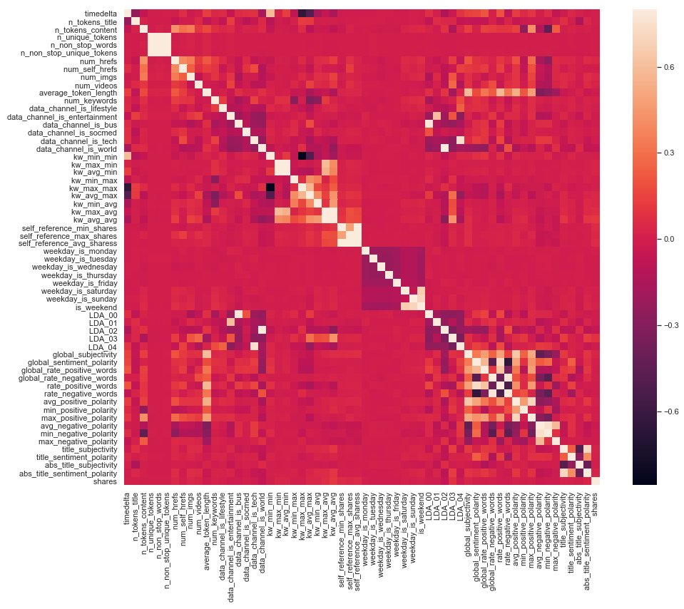

```python
corr = dataset.corr()
dims = (16.7, 12.27)
fig, ax = plt.subplots(figsize=dims)
sns.heatmap(corr,  vmax=.8, square=True )
```

```python
c = dataset.columns[60]
```

### Heatmap for most Correlated Features of all

Top 20 features

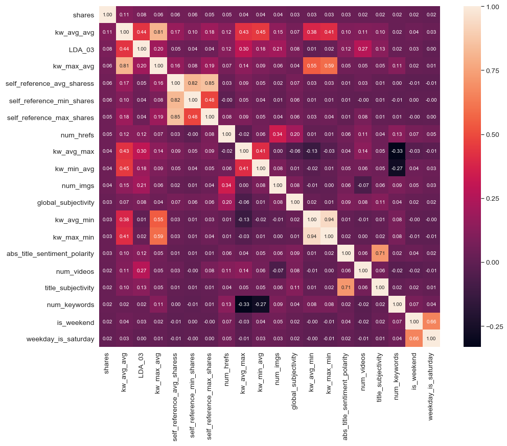

```python
k = 20 #number of variables for heatmap
cols = corr.nlargest(k, c).index
cm = np.corrcoef(dataset[cols].values.T)
sns.set(font_scale=1.25)
fig, ax = plt.subplots(figsize=dims)
hm = sns.heatmap(cm, cbar=True, annot=True, square=True, fmt='.2f', annot_kws={'size': 10}, yticklabels=cols.values, xticklabels=cols.values)
plt.show()
```

```python
most_corr = pd.DataFrame(cols)
most_corr.columns = ['Most Correlated Features']
most_corr
```

|  | Most Correlated Features |
| --- | --- |
| 0 | shares |
| 1 | kw_avg_avg |
| 2 | LDA_03 |
| 3 | kw_max_avg |
| 4 | self_reference_avg_sharess |
| 5 | self_reference_min_shares |
| 6 | self_reference_max_shares |
| 7 | num_hrefs |
| 8 | kw_avg_max |
| 9 | kw_min_avg |
| 10 | num_imgs |
| 11 | global_subjectivity |
| 12 | kw_avg_min |
| 13 | kw_max_min |
| 14 | abs_title_sentiment_polarity |
| 15 | num_videos |
| 16 | title_subjectivity |
| 17 | num_keywords |
| 18 | is_weekend |
| 19 | weekday_is_saturday |

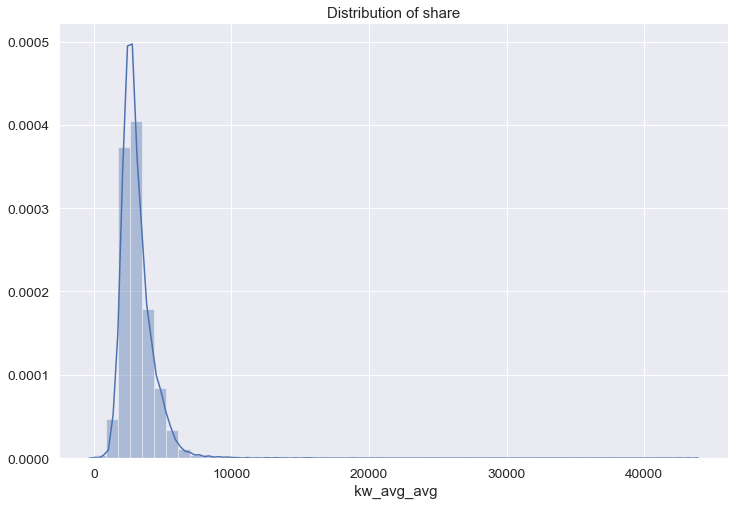

```python
plt.figure()
sns.distplot(dataset.iloc[:,27])
plt.title('Distribution of share')
plt.show()
```

### Checking Skewness and Kurtosis Values to check the perfection of the normal distribution

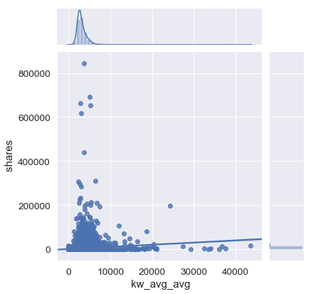

```python
#Plotting features with high correlation
sns.jointplot(x= dataset.iloc[:, 27], y= dataset.iloc[:, 60], kind ='reg')
```

```python
print("Skewness: %f" % dataset.iloc[:,60].skew())
print("Kurtosis: %f" % dataset.iloc[:,60].kurt())
```

```
Skewness: 33.963885
Kurtosis: 1832.672657
```

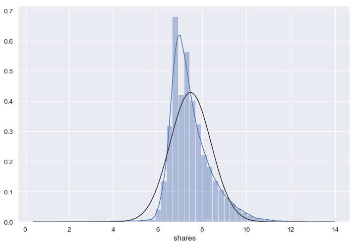

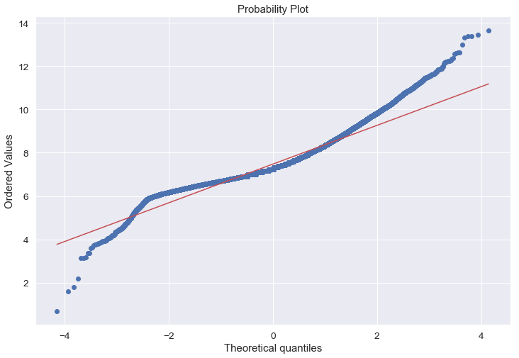

```
Skewness: 1.026477
Kurtosis: 2.384471
```

```python
 # log1p insures a more homogeneous distribution when a dataset contains numbers close to zero which is more suitable in our case


# Applying log1p for shares and visualizing the skewness again

dataset.iloc[:,60] = np.log1p(dataset.iloc[:,60])

sns.distplot(dataset.iloc[:,60], fit=norm);

fig = plt.figure()
res = stats.probplot(dataset.iloc[:,60], plot=plt)
plt.show()

y_train = dataset.iloc[:,60].values

print("Skewness: %f" % dataset.iloc[:,60].skew())
print("Kurtosis: %f" % dataset.iloc[:,60].kurt())
```

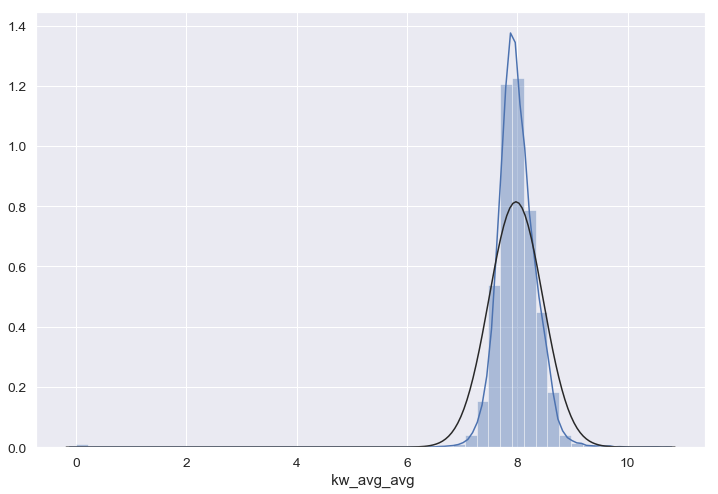

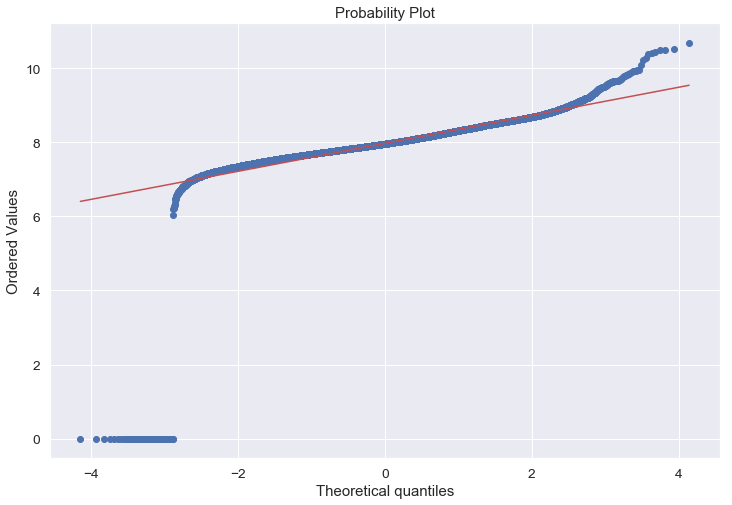

```
Skewness: -8.429219
Kurtosis: 138.697598
```

```python
# Applying log1p for avg keywords(average share) and visualizing the skewness again

dataset.iloc[:, 27] = np.log1p(dataset.iloc[:, 27])

sns.distplot(dataset.iloc[:, 27], fit=norm);

fig = plt.figure()
res = stats.probplot(dataset.iloc[:, 27], plot=plt)
plt.show()

y_train = dataset.iloc[:, 27].values

print("Skewness: %f" % dataset.iloc[:, 27].skew())
print("Kurtosis: %f" % dataset.iloc[:, 27].kurt())
```

```python
s = dataset.describe().loc['std']  # Getting standard deviation of each feature
s.head(20)
```

```
 timedelta                         214.163767
 n_tokens_title                      2.114037
 n_tokens_content                  471.107508
 n_unique_tokens                     3.520708
 n_non_stop_words                    5.231231
 n_non_stop_unique_tokens            3.264816
 num_hrefs                          11.332017
 num_self_hrefs                      3.855141
 num_imgs                            8.309434
 num_videos                          4.107855
 average_token_length                0.844406
 num_keywords                        1.909130
 data_channel_is_lifestyle           0.223929
 data_channel_is_entertainment       0.382525
 data_channel_is_bus                 0.364610
 data_channel_is_socmed              0.234871
 data_channel_is_tech                0.388545
 data_channel_is_world               0.409129
 kw_min_min                         69.633215
 kw_max_min                       3857.990877
Name: std, dtype: float64
```

### Fixing "skewed" features.

Here, we fix all of the skewed data to be more normal so that our models will be more accurate when making predictions.

```python
#Drop first two columns because they are irrelevant
df = dataset.drop(dataset.columns[[0,1]],axis=1)
```

```python
numeric_feats = df.index

# Check the skew of all numerical features
skewed_feats = df.apply(lambda x: skew(x.dropna())).sort_values(ascending=False)
skewness = pd.DataFrame({'Skewed Features' :skewed_feats})
skewness.head()
```

|  | Skewed Features |
| --- | --- |
| n_non_stop_words | 198.784924 |
| n_unique_tokens | 198.647599 |
| n_non_stop_unique_tokens | 198.435786 |
| kw_max_min | 35.327097 |
| kw_avg_min | 31.304924 |

```python
skewness = skewness[abs(skewness) > 0.75]
print("There are {} skewed numerical features to Box Cox transform".format(skewness.shape[0]))

from scipy.special import boxcox1p
skewed_features = skewness.index
lam = 0.15
for feat in skewed_features:
    df[feat] = boxcox1p(df[feat], lam)
    df[feat] += 1
```

```
There are 59 skewed numerical features to Box Cox transform
```

# Splitting data

```python
from sklearn.model_selection import train_test_split
```

```python
df.head()
```

|  | n_tokens_title | n_tokens_content | n_unique_tokens | n_non_stop_words | n_non_stop_unique_tokens | num_hrefs | num_self_hrefs | num_imgs | num_videos | average_token_length | ... | min_positive_polarity | max_positive_polarity | avg_negative_polarity | min_negative_polarity | max_negative_polarity | title_subjectivity | title_sentiment_polarity | abs_title_subjectivity | abs_title_sentiment_polarity | shares |
| --- | --- | --- | --- | --- | --- | --- | --- | --- | --- | --- | --- | --- | --- | --- | --- | --- | --- | --- | --- | --- | --- |
| 0 | 4.128239 | 9.305069 | 1.528914 | 1.730463 | 1.623778 | 2.820334 | 2.194318 | 1.730463 | 1.0 | 2.984311 | ... | 1.095995 | 1.552317 | 0.582840 | 0.143890 | 0.780550 | 1.418049 | 0.795561 | 1.000000 | 1.174084 | 3.331994 |
| 1 | 3.750250 | 9.649311 | 1.490145 | 1.730463 | 1.609581 | 2.540963 | 1.730463 | 1.730463 | 1.0 | 3.036713 | ... | 1.032871 | 1.552317 | 0.874777 | 0.867797 | 0.895468 | 1.000000 | 1.000000 | 1.418049 | 1.000000 | 3.364765 |
| 2 | 3.750250 | 9.222114 | 1.470177 | 1.730463 | 1.529090 | 2.540963 | 1.730463 | 1.730463 | 1.0 | 2.917294 | ... | 1.095995 | 1.730463 | 0.400118 | -0.429900 | 0.858424 | 1.000000 | 1.000000 | 1.418049 | 1.000000 | 3.492993 |
| 3 | 3.750250 | 11.425436 | 1.420730 | 1.730463 | 1.530237 | 3.750250 | 1.000000 | 1.730463 | 1.0 | 2.920044 | ... | 1.129067 | 1.614477 | 0.554060 | 0.143890 | 0.820149 | 1.000000 | 1.000000 | 1.418049 | 1.000000 | 3.455717 |
| 4 | 4.237728 | 13.322185 | 1.356806 | 1.730463 | 1.446688 | 4.782057 | 4.782057 | 4.858807 | 1.0 | 2.984875 | ... | 1.032871 | 1.730463 | 0.755874 | 0.341670 | 0.948904 | 1.385423 | 1.129067 | 1.044600 | 1.129067 | 3.302421 |

5 rows × 59 columns

```python
print(df.columns)
```

```
Index([' n_tokens_title', ' n_tokens_content', ' n_unique_tokens',
       ' n_non_stop_words', ' n_non_stop_unique_tokens', ' num_hrefs',
       ' num_self_hrefs', ' num_imgs', ' num_videos', ' average_token_length',
       ' num_keywords', ' data_channel_is_lifestyle',
       ' data_channel_is_entertainment', ' data_channel_is_bus',
       ' data_channel_is_socmed', ' data_channel_is_tech',
       ' data_channel_is_world', ' kw_min_min', ' kw_max_min', ' kw_avg_min',
       ' kw_min_max', ' kw_max_max', ' kw_avg_max', ' kw_min_avg',
       ' kw_max_avg', ' kw_avg_avg', ' self_reference_min_shares',
       ' self_reference_max_shares', ' self_reference_avg_sharess',
       ' weekday_is_monday', ' weekday_is_tuesday', ' weekday_is_wednesday',
       ' weekday_is_thursday', ' weekday_is_friday', ' weekday_is_saturday',
       ' weekday_is_sunday', ' is_weekend', ' LDA_00', ' LDA_01', ' LDA_02',
       ' LDA_03', ' LDA_04', ' global_subjectivity',
       ' global_sentiment_polarity', ' global_rate_positive_words',
       ' global_rate_negative_words', ' rate_positive_words',
       ' rate_negative_words', ' avg_positive_polarity',
       ' min_positive_polarity', ' max_positive_polarity',
       ' avg_negative_polarity', ' min_negative_polarity',
       ' max_negative_polarity', ' title_subjectivity',
       ' title_sentiment_polarity', ' abs_title_subjectivity',
       ' abs_title_sentiment_polarity', ' shares'],
      dtype='object')
```

```python
# highly correlated features
cols
```

```
Index([' shares', ' kw_avg_avg', ' LDA_03', ' kw_max_avg',
       ' self_reference_avg_sharess', ' self_reference_min_shares',
       ' self_reference_max_shares', ' num_hrefs', ' kw_avg_max',
       ' kw_min_avg', ' num_imgs', ' global_subjectivity', ' kw_avg_min',
       ' kw_max_min', ' abs_title_sentiment_polarity', ' num_videos',
       ' title_subjectivity', ' num_keywords', ' is_weekend',
       ' weekday_is_saturday'],
      dtype='object')
```

```python
X =df.iloc[:,[25,40,24,28,26,27,5,22,23,7,42,19,18,57,8,54,10,36,34]]
y = df.iloc[:, -1]
```

```python
X_train, X_test, y_train, y_test = train_test_split(X, y, test_size = 0.3, random_state = 0)
```

```python
X_train.head()
```

|  | kw_avg_avg | LDA_03 | kw_max_avg | self_reference_avg_sharess | self_reference_min_shares | self_reference_max_shares | num_hrefs | kw_avg_max | kw_min_avg | num_imgs | global_subjectivity | kw_avg_min | kw_max_min | abs_title_sentiment_polarity | num_videos | title_subjectivity | num_keywords | is_weekend | weekday_is_saturday |
| --- | --- | --- | --- | --- | --- | --- | --- | --- | --- | --- | --- | --- | --- | --- | --- | --- | --- | --- | --- |
| 15251 | 3.549609 | 1.032983 | 16.794432 | 16.261671 | 16.261671 | 16.261671 | 3.055642 | 35.785550 | 1.000000 | 3.259674 | 1.444446 | 8.284379 | 11.406097 | 1.000000 | 1.0 | 1.000000 | 3.259674 | 1.0 | 1.0 |
| 11871 | 3.649161 | 1.024824 | 19.242252 | 17.466443 | 17.466443 | 17.466443 | 3.440268 | 37.846086 | 16.232318 | 1.730463 | 1.418861 | 11.502163 | 15.760639 | 1.000000 | 1.0 | 1.000000 | 3.602594 | 1.0 | 1.0 |
| 2487 | 3.581431 | 1.040374 | 17.455357 | 1.000000 | 1.000000 | 1.000000 | 4.340760 | 26.839518 | 13.256508 | 1.000000 | 1.338331 | 10.528485 | 11.697217 | 1.418049 | 1.0 | 1.418049 | 3.055642 | 1.0 | 1.0 |
| 28360 | 3.574123 | 1.039695 | 17.041112 | 14.680989 | 14.680989 | 14.680989 | 2.540963 | 36.462398 | 15.212720 | 1.730463 | 1.369562 | 8.417784 | 10.466329 | 1.000000 | 1.0 | 1.000000 | 3.055642 | 1.0 | 1.0 |
| 8964 | 3.565928 | 1.039405 | 16.752691 | 13.091405 | 13.091405 | 13.091405 | 3.885846 | 37.939487 | 13.878993 | 1.730463 | 1.350260 | 10.410978 | 13.878993 | 1.000000 | 1.0 | 1.000000 | 3.055642 | 1.0 | 1.0 |

# Modeling and Prediction

### linear Regression

```python
from sklearn.linear_model import LinearRegression
from sklearn.tree import DecisionTreeRegressor
from sklearn.ensemble import RandomForestRegressor
from sklearn.model_selection import GridSearchCV
from sklearn.linear_model import Lasso
from sklearn.model_selection import train_test_split, GridSearchCV, KFold, RandomizedSearchCV
from sklearn.metrics import mean_squared_error
from sklearn.metrics import r2_score
from sklearn import metrics
import xgboost as xgb
```

```python
#implementing linear regression model

regressor = LinearRegression()
regressor.fit(X_train, y_train)
```

```
LinearRegression(copy_X=True, fit_intercept=True, n_jobs=1, normalize=False)
```

```python
train_pred = regressor.predict(X_train)
test_pred = regressor.predict(X_test)
```

```python
print('Train data R^2 score:',metrics.r2_score(y_train, train_pred))
print('Test data R^2 score:',metrics.r2_score(y_test, test_pred))
print('Train data RMSE:', np.sqrt(metrics.mean_squared_error(y_train, train_pred)))
print('Test data RMSE:', np.sqrt(metrics.mean_squared_error(y_test, test_pred)))
```

```
Train data R^2 score: 0.074341417583073
Test data R^2 score: 0.07274262477855498
Train data RMSE: 0.14208249830345532
Test data RMSE: 0.13961788404112715
```

### Decision Tree Regressor

```python
#Decision Tree Regressor
reg = DecisionTreeRegressor(max_depth=5,random_state=0)
reg.fit(X_train, y_train)
```

```
DecisionTreeRegressor(criterion='mse', max_depth=5, max_features=None,
           max_leaf_nodes=None, min_impurity_decrease=0.0,
           min_impurity_split=None, min_samples_leaf=1,
           min_samples_split=2, min_weight_fraction_leaf=0.0,
           presort=False, random_state=0, splitter='best')
```

```python
train_pred = reg.predict(X_train)
test_pred = reg.predict(X_test)
```

```python
print('Train data R^2 score:',metrics.r2_score(y_train, train_pred))
print('Test data R^2 score:',metrics.r2_score(y_test, test_pred))
print('Train data RMSE:', np.sqrt(metrics.mean_squared_error(y_train, train_pred)))
print('Test data RMSE:', np.sqrt(metrics.mean_squared_error(y_test, test_pred)))
```

```
Train data R^2 score: 0.12048121932397415
Test data R^2 score: 0.09096834226904116
Train data RMSE: 0.1384961585534222
Test data RMSE: 0.13823894404696435
```

### Randmon Forest Regressor

```python
randomForest_model = RandomForestRegressor ( n_estimators  =  150 , random_state  =  0 )
randomForest_model.fit ( X_train , y_train )
```

```
RandomForestRegressor(bootstrap=True, criterion='mse', max_depth=None,
           max_features='auto', max_leaf_nodes=None,
           min_impurity_decrease=0.0, min_impurity_split=None,
           min_samples_leaf=1, min_samples_split=2,
           min_weight_fraction_leaf=0.0, n_estimators=150, n_jobs=1,
           oob_score=False, random_state=0, verbose=0, warm_start=False)
```

```python
train_pred = randomForest_model.predict(X_train)
test_pred = randomForest_model.predict(X_test)
```

```python
print('Train data R^2 score:',metrics.r2_score(y_train, train_pred))
print('Test data R^2 score:',metrics.r2_score(y_test, test_pred))
print('Train data RMSE:', np.sqrt(metrics.mean_squared_error(y_train, train_pred)))
print('Test data RMSE:', np.sqrt(metrics.mean_squared_error(y_test, test_pred)))
```

```
Train data R^2 score: 0.8802745562307891
Test data R^2 score: 0.1262585444091726
Train data RMSE: 0.05109852882525936
Test data RMSE: 0.1355290438956252
```

### Xgboost

```python
#Xgboost
xgb_model = xgb.XGBRegressor(objective="reg:linear", random_state=42)
xgb_model.fit(X_train, y_train)
```

```
XGBRegressor(base_score=0.5, booster='gbtree', colsample_bylevel=1,
       colsample_bytree=1, gamma=0, importance_type='gain',
       learning_rate=0.1, max_delta_step=0, max_depth=3,
       min_child_weight=1, missing=None, n_estimators=100, n_jobs=1,
       nthread=None, objective='reg:linear', random_state=42, reg_alpha=0,
       reg_lambda=1, scale_pos_weight=1, seed=None, silent=True,
       subsample=1)
```

```python
train_pred = xgb_model.predict(X_train)
test_pred = xgb_model.predict(X_test)
```

```python
print('Train data R^2 score:',metrics.r2_score(y_train, train_pred))
print('Test data R^2 score:',metrics.r2_score(y_test, test_pred))
print('Train data RMSE:', np.sqrt(metrics.mean_squared_error(y_train, train_pred)))
print('Test data RMSE:', np.sqrt(metrics.mean_squared_error(y_test, test_pred)))
```

```
Train data R^2 score: 0.17928052761468527
Test data R^2 score: 0.139317231475804
Train data RMSE: 0.13378657558930807
Test data RMSE: 0.13451244219292002
```

```
Text(0,0.5,'Predicted Y')
```

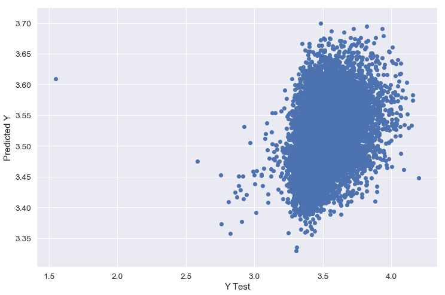

```python
plt.scatter(y_test,test_pred)
plt.xlabel('Y Test')
plt.ylabel('Predicted Y')
```

### Lasso Regression

```python
lasso = Lasso()
```

```python
parameters = {"alpha": [0.1, 1.0, 2, 5, 10]}
```

```python
lasso_reg = GridSearchCV(lasso, parameters, scoring='neg_mean_squared_error', cv = 5  )
```

```python
lasso_reg.fit(X_train, y_train)
```

```
GridSearchCV(cv=5, error_score='raise',
       estimator=Lasso(alpha=1.0, copy_X=True, fit_intercept=True, max_iter=1000,
   normalize=False, positive=False, precompute=False, random_state=None,
   selection='cyclic', tol=0.0001, warm_start=False),
       fit_params=None, iid=True, n_jobs=1,
       param_grid={'alpha': [0.1, 1.0, 2, 5, 10]}, pre_dispatch='2*n_jobs',
       refit=True, return_train_score='warn',
       scoring='neg_mean_squared_error', verbose=0)
```

```python
train_pred = lasso_reg.predict(X_train)
test_pred =  lasso_reg.predict(X_test)
```

```python
print('Train data R^2 score:',metrics.r2_score(y_train, train_pred))
print('Test data R^2 score:',metrics.r2_score(y_test, test_pred))
print('Train data RMSE:', np.sqrt(metrics.mean_squared_error(y_train, train_pred)))
print('Test data RMSE:', np.sqrt(metrics.mean_squared_error(y_test, test_pred)))
```

```
Train data R^2 score: 0.011926112772257969
Test data R^2 score: 0.011592443019315501
Train data RMSE: 0.14679453237487525
Test data RMSE: 0.14414810328561856
```

# Tunning Hyperparameter

### Xgboost

```python
# Tuning hyper-parameters by GridSearchCV
param_grid = {'max_depth': [int(x) for x in np.linspace(3, 30, 3)],
              'min_child_weight': [1, 3, 5],
              'subsample': [i/10.0 for i in range(6, 10)],
              }
tuned_xgboost  = GridSearchCV(estimator = xgb.XGBRegressor(learning_rate = 0.1, n_estimators = 200, colsample_bytree = 0.8, objective= 'reg:linear',
                                            nthread = 4, scale_pos_weight = 1, seed = 27), param_grid = param_grid, scoring = 'neg_mean_squared_error',
                                            n_jobs = -1, iid = False, cv = 4)
tuned_xgboost.fit(X_train, y_train)
```

```
GridSearchCV(cv=4, error_score='raise',
       estimator=XGBRegressor(base_score=0.5, booster='gbtree', colsample_bylevel=1,
       colsample_bytree=0.8, gamma=0, importance_type='gain',
       learning_rate=0.1, max_delta_step=0, max_depth=3,
       min_child_weight=1, missing=None, n_estimators=200, n_jobs=1,
       nthread=4, objective='reg:linear', random_state=0, reg_alpha=0,
       reg_lambda=1, scale_pos_weight=1, seed=27, silent=True, subsample=1),
       fit_params=None, iid=False, n_jobs=-1,
       param_grid={'max_depth': [3, 16, 30], 'min_child_weight': [1, 3, 5], 'subsample': [0.6, 0.7, 0.8, 0.9]},
       pre_dispatch='2*n_jobs', refit=True, return_train_score='warn',
       scoring='neg_mean_squared_error', verbose=0)
```

```python
tuned_xgboost.best_params_
```

```
{'max_depth': 3, 'min_child_weight': 1, 'subsample': 0.9}
```

```python
train_pred = tuned_xgboost.predict(X_train)
test_pred = tuned_xgboost.predict(X_test)
```

```python
print('After tuning hyperparameter of Xgboost  ')
print('Train data R^2 score is:',metrics.r2_score(y_train, train_pred))
print('Test data R^2 score is:',metrics.r2_score(y_test, test_pred))
print('Train data RMSE is :', np.sqrt(metrics.mean_squared_error(y_train, train_pred)))
print('Test data RMSE is:', np.sqrt(metrics.mean_squared_error(y_test, test_pred)))
```

```
After tuning hyperparameter of Xgboost
Train data R^2 score is: 0.20623950108159694
Test data R^2 score is: 0.14107357252217467
Train data RMSE is : 0.1315709196065126
Test data RMSE is: 0.13437512657546838
```

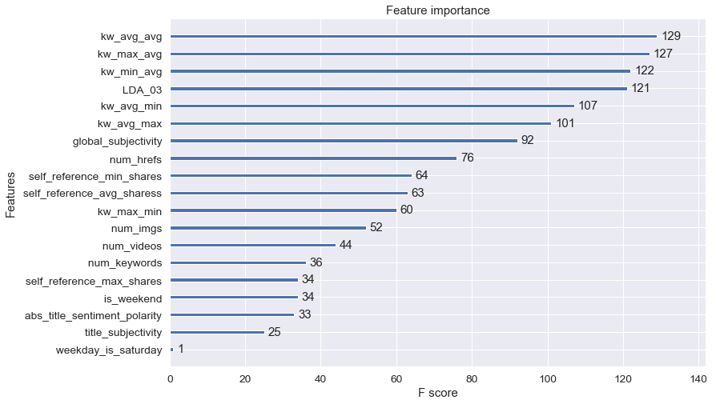

```python
best_estimator  =  tuned_xgboost.best_estimator_
xgb.plot_importance(best_estimator,max_num_features=20)
plt.show()
```

### Random Forest Regressor

```python
# preparing list of hyperparameter.
n_estimators = [int(x) for x in np.linspace(start = 100, stop = 1000, num = 10)]
max_features = ['auto', 'sqrt']
max_depth = [int(x) for x in np.linspace(3, 30, num = 3)]
min_samples_split = [2, 5, 10]
min_samples_leaf = [1, 2, 4]
bootstrap = [True, False]
# creating random grid
random_grid = {'n_estimators': n_estimators,
               'max_features': max_features,
               'max_depth': max_depth,
               'min_samples_split': min_samples_split,
               'min_samples_leaf': min_samples_leaf,
               'bootstrap': bootstrap}
```

```python
# Tuning hyper-parameters by RandomizedSearchCV
tune_rf = RandomizedSearchCV(estimator = RandomForestRegressor(), param_distributions = random_grid, n_iter = 100, cv = 3, scoring = 'neg_mean_squared_error', verbose=2, random_state = 42, n_jobs = -1)
tune_rf.fit(X_train, y_train)
```

```
Fitting 3 folds for each of 100 candidates, totalling 300 fits
```

```
[Parallel(n_jobs=-1)]: Done  25 tasks      | elapsed:  5.5min
[Parallel(n_jobs=-1)]: Done 146 tasks      | elapsed: 38.4min
[Parallel(n_jobs=-1)]: Done 300 out of 300 | elapsed: 74.0min finished
```

```
RandomizedSearchCV(cv=3, error_score='raise',
          estimator=RandomForestRegressor(bootstrap=True, criterion='mse', max_depth=None,
           max_features='auto', max_leaf_nodes=None,
           min_impurity_decrease=0.0, min_impurity_split=None,
           min_samples_leaf=1, min_samples_split=2,
           min_weight_fraction_leaf=0.0, n_estimators=10, n_jobs=1,
           oob_score=False, random_state=None, verbose=0, warm_start=False),
          fit_params=None, iid=True, n_iter=100, n_jobs=-1,
          param_distributions={'n_estimators': [100, 200, 300, 400, 500, 600, 700, 800, 900, 1000], 'max_features': ['auto', 'sqrt'], 'max_depth': [3, 16, 30], 'min_samples_split': [2, 5, 10], 'min_samples_leaf': [1, 2, 4], 'bootstrap': [True, False]},
          pre_dispatch='2*n_jobs', random_state=42, refit=True,
          return_train_score='warn', scoring='neg_mean_squared_error',
          verbose=2)
```

```python
tune_rf.best_params_
```

```
{'n_estimators': 900,
 'min_samples_split': 5,
 'min_samples_leaf': 4,
 'max_features': 'sqrt',
 'max_depth': 30,
 'bootstrap': True}
```

```python
train_pred = tune_rf.predict(X_train)
test_pred = tune_rf.predict(X_test)
```

```python
print('tuned random forest regressor Train data R^2 score is:',metrics.r2_score(y_train, train_pred))
print('tuned random forest regressor Test data R^2 score is:',metrics.r2_score(y_test, test_pred))
print('tuned random forest regressor Train data RMSE is :', np.sqrt(metrics.mean_squared_error(y_train, train_pred)))
print('tuned random forest regressor Test data RMSE is:', np.sqrt(metrics.mean_squared_error(y_test, test_pred)))
```

```
tuned random forest regressor Train data R^2 score is: 0.6133201841618121
tuned random forest regressor Test data R^2 score is: 0.1446252539983771
tuned random forest regressor Train data RMSE is : 0.09183133974768362
tuned random forest regressor Test data RMSE is: 0.13409701658647888
```

[figure not shown]

```python
features = df.columns
best_estimator  =  tune_rf.best_estimator_
importances = best_estimator.feature_importances_
indices = np.argsort(importances)
plt.title('Feature Importances')
plt.barh(range(len(indices)), importances[indices], color='b', align='center')
plt.yticks(range(len(indices)), [features[i] for i in indices])
plt.xlabel('Relative Importance')
plt.show()
```

# Conclusion

After completing the different stages of the process: Preparation, Exploration, and Modeling, and by applying the different regressions models. I have come to conclusion that Random Forest regressor after hyper parameter tuning has the best RMSE 0.1340970 and the best R squared 0.14462525 on test set.